# 5. ggplot2（散布図）

# 6. 米国下院の政治的二極化の散布図

## 6.1 データの準備

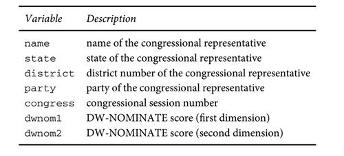

- 米国下院議員を対象とした実施したサーベイデータ( congress.csv) をダウンロードする
- データを読み込み `congress` と名前をつける

```r
congress <- read_csv("data/congress.csv")
```

- 変数を確認する

```r
names(congress)
```

```
[1] "congress" "district" "state"    "party"    "name"     "dwnom1"   "dwnom2"
```

- 変数の最初の部分だけ表示

```r
head(congress)
```

```
# A tibble: 6 × 7
  congress district state   party    name          dwnom1 dwnom2
     <dbl>    <dbl> <chr>   <chr>    <chr>          <dbl>  <dbl>
1       80        0 USA     Democrat TRUMAN      -0.276   0.0160
2       80        1 ALABAMA Democrat BOYKIN  F.  -0.0260  0.796
3       80        2 ALABAMA Democrat GRANT  G.   -0.0420  0.999
4       80        3 ALABAMA Democrat ANDREWS  G. -0.00800 1.00
5       80        4 ALABAMA Democrat HOBBS  S.   -0.0820  1.07
6       80        5 ALABAMA Democrat RAINS  A.   -0.170   0.870
```

```r
tail(congress)
```

```
# A tibble: 6 × 7
  congress district state   party      name     dwnom1   dwnom2
     <dbl>    <dbl> <chr>   <chr>      <chr>     <dbl>    <dbl>
1      112        4 WISCONS Democrat   MOORE    -0.538 -0.458
2      112        5 WISCONS Republican SENSENBR  1.20  -0.438
3      112        6 WISCONS Republican PETRI     0.776 -0.00300
4      112        7 WISCONS Republican DUFFY     0.781 -0.270
5      112        8 WISCONS Republican RIBBLE    0.886 -0.193
6      112        1 WYOMING Republican LUMMIS    0.932 -0.211
```

- `filter()` 関数を使って、議会ごとにデータを抜き出す

```r
eighty <- congress %>%
  filter(congress == 80)  # 第80回議会

twelve <- congress %>%
  filter(congress == 112) # 第112回議会
```

- 抜き出した第80回議会データの文頭を表示

```r
head(eighty)
```

```
# A tibble: 6 × 7
  congress district state   party    name          dwnom1 dwnom2
     <dbl>    <dbl> <chr>   <chr>    <chr>          <dbl>  <dbl>
1       80        0 USA     Democrat TRUMAN      -0.276   0.0160
2       80        1 ALABAMA Democrat BOYKIN  F.  -0.0260  0.796
3       80        2 ALABAMA Democrat GRANT  G.   -0.0420  0.999
4       80        3 ALABAMA Democrat ANDREWS  G. -0.00800 1.00
5       80        4 ALABAMA Democrat HOBBS  S.   -0.0820  1.07
6       80        5 ALABAMA Democrat RAINS  A.   -0.170   0.870
```

## 6.2 第80回議会のデータの散布図

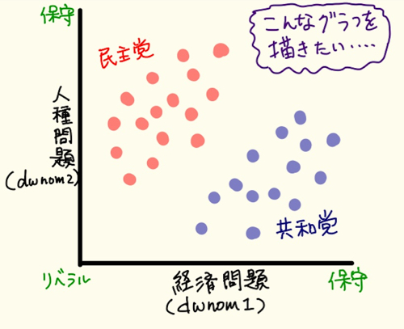

- 第80回議会のデータの散布図を描いてみる

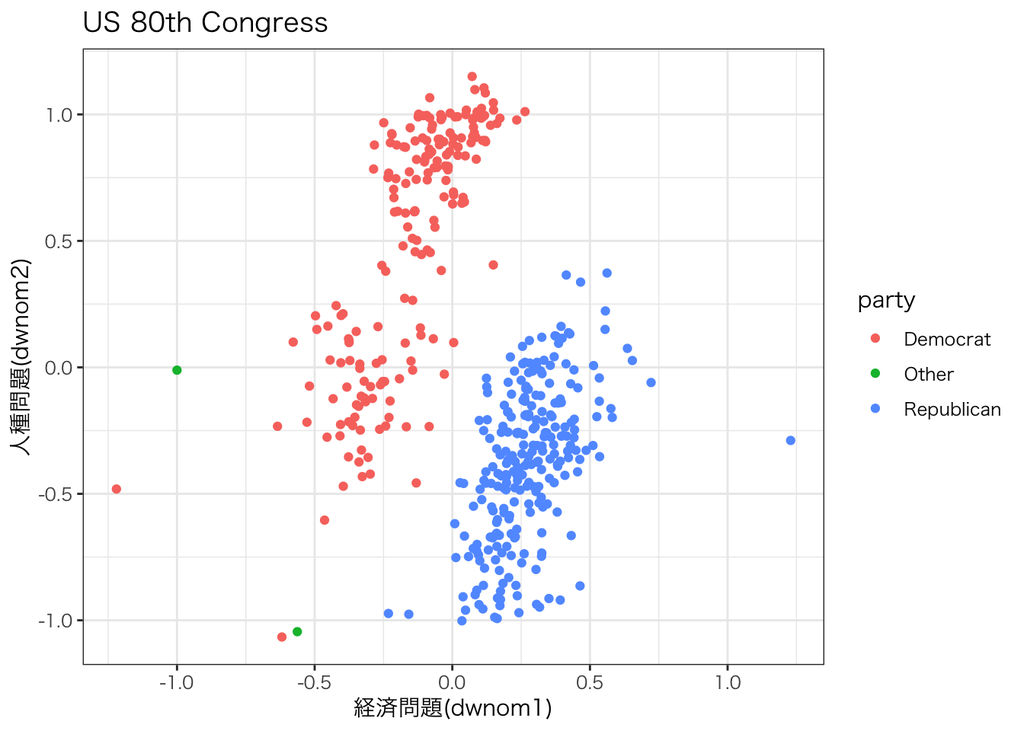

```r
eighty %>%
  ggplot(aes(x = dwnom1, y = dwnom2)) +
  geom_point(aes(color = party)) +
  labs(x = "経済問題(dwnom1)",
       y = "人種問題(dwnom2)") +
  ggtitle("US 80th Congress") +
  theme_bw(base_family = "HiraKakuProN-W3")
```

- 人種問題（y 軸）に関して、民主党議員の方が保守的 = グラフの上側（＋）に集中している
- 経済問題に（x 軸）に関して、共和党議員の方が保守的 = グラフの右側（＋）に集中している

## 6.3 第112回議会のデータの散布図

- 第112回議会のデータの散布図

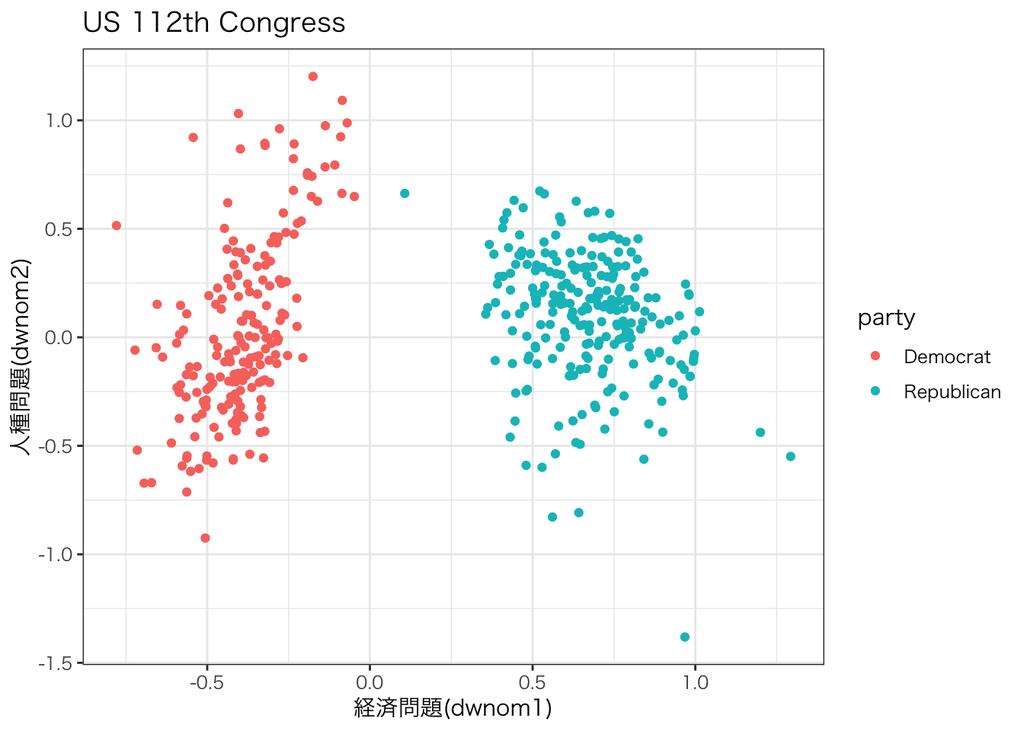

```r
twelve %>%
  ggplot(aes(x = dwnom1, y = dwnom2)) +
  geom_point(aes(color = party)) +
  labs(x = "経済問題(dwnom1)",
       y = "人種問題(dwnom2)") +
  ggtitle("US 112th Congress") +
  theme_bw(base_family = "HiraKakuProN-W3")
```

# 7. Exercise

- **Q7.1**:  
  `「1.3 ドットの形をカスタマイズ」`を参考にして、2009年衆院選における「選挙費用」と「得票率」の散布図を描きなさい  
  ・その際、`shape = 23` を使い「内側が `yellow`」で「枠線が `magenta`」の「`◇`」を表示させなさい
- **Q7.2**:  
  `「2.2 ドットの色を変えて次元追加」`を参考にして、2009年衆院選における「選挙費用」と「得票率」の散布図を描きなさい  
  ・その際、自民党候補者とそれ以外の候補者を色分けして表示させなさい
- **Q7.3**:  
  `「2.4 ドットの色を指定する」`を参考にして、2009年衆院選における「選挙費用」と「得票率」の散布図を描きなさい  
  ・その際、自民党候補者を `red`、それ以外の候補者を `grey` に色分けして表示させなさい
- **Q7.4**:  
  ・**Q1:**`「3. 回帰直線を加えた散布図 (1)」`を参考にして、2005年衆院選における「選挙費用」と「得票率」の散布図を描きなさい  
  ・その際、`facet_wrap()` 関数を使って政党ごとに散布図を表示させ、自民党と民主党が隣同士になるよう留意しなさい  
  ・**Q2:**:`group_by()` 関数を使って、政党別の得票率を計算し `DT::datatable()` 関数を使って結果を表示させなさい
- **Q7.5**:  
  ・**Q1:**`「4.5 特定の国をハイライトして表示」`を参考にして、`{gapminder}` を使って「一人あたりGDP (USD)の対数値」と 「寿命」の散布図を表示させなさい  
  ・その際、自分が興味ある国を 3 つ選び、色別に表示させなさい  
  ・**Q2:** 上のグラフからわかることを簡潔にまとめなさい
- **Q7.6**:  
  ・**Q1**:`「5.2 次元を加えた散布図（都道府県）」`を参考にして、第24回 (2016) 参議院議員選挙において、「都道府県の人口密度 (`did`)」を `x` 軸、「19歳有権者の投票率 (`age19`)」を `y` 軸とした散布図を描きなさい  
  ・必要に応じて変数を対数変換すること  
  ・**Q2**: 上のグラフからわかることを簡潔にまとめなさい

**参考文献**

[Tidy Animated Verbs](https://github.com/gadenbuie/tidyexplain?fbclid=IwAR3Zt0pQZa0IEvP-1gstatQ42VM5yJZvw2vUaFEqt_m2smUgtZpTqvuurLJ6z0)

[宋財泫 (Jaehyun Song)・矢内勇生 (statuki statanai)「私たちのR: ベストプラクティスの探究」](https://www.jaysong.net/RBook/)

[宋財泫「ミクロ政治データ分析実習（2022年度）」](https://www.jaysong.net/micro-book/)

[土井翔平（北海道大学公共政策大学院）「Rで計量政治学入門」](https://shohei-doi.github.io/quant_polisci/data-import.html)

[矢内勇生（高知工科大学）授業一覧](http://yukiyanai.github.io/teaching/)

浅野正彦, 矢内勇生.『Rによる計量政治学』オーム社、2018年

浅野正彦, 中村公亮.『初めてのRStudio』オーム社、2018年

Kieran Healy, DATA VISUALIZATION, Princeton, 2019

Kosuke Imai, Quantitative Social Science: An Introduction, Princeton University Press, 2017